# Regression Analysis on House Prices

After exploring the data and already finding some apparent relationships, we are going to build some regression models to predict the house prices.

Author: Julia Hammerer, Vanessa Mai  
Last Changes: 09.12.2018

We can also have a look at the Kaggle Leaderboard for comparison:

[figure not shown]

# Table of Contents

```python
import sys
sys.path.insert(0, '../helper/')
```

```python
# load packages
%matplotlib inline
import numpy as np
import pandas as pd
import seaborn as sns
import pandas_profiling
import missingno as msno
import matplotlib.pyplot as plt
import plotly.graph_objs as go
import warnings
import math
import statsmodels.formula.api as smf
import statsmodels.api as sm

from statsmodels.compat import lzip
from slugify import slugify
from pandas.tools.plotting import table
from plotly.offline import init_notebook_mode
from plotly.offline import iplot
from plotly.offline import plot
from scipy.stats import mannwhitneyu
from statsmodels.distributions.empirical_distribution import ECDF
from scipy import stats
from scipy.stats import pearsonr
from scipy.stats import norm
from sklearn.metrics import mean_squared_error, r2_score,explained_variance_score
from sklearn.dummy import DummyClassifier, DummyRegressor
from sklearn.model_selection import StratifiedKFold, cross_val_score, train_test_split, KFold, cross_val_predict
from sklearn.preprocessing import StandardScaler
from sklearn.linear_model import Lasso, LassoCV, ElasticNetCV, ElasticNet
from sklearn.neighbors import KNeighborsRegressor
from sklearn.cross_decomposition import PLSRegression, PLSSVD
from math import sqrt
from sklearn.decomposition.pca import PCA
from sklearn.linear_model import LinearRegression
import xgboost as xgb
from sklearn.model_selection import GridSearchCV
from sklearn.feature_selection import RFE

from helper import na_ratio_table
from helper import rmsle
from helper import reg_line
from helper import reg_model_results_plots
from helper import regression_model_metrics
from helper import results_summary_to_dataframe
from helper import lin_model
from helper import get_model_results
from helper import reg_model_results_plots
from helper import resid_plot
from helper import cross_fold
from helper import get_baseline_for_regression
from helper import outliers_idx
```

```python
warnings.filterwarnings('ignore')
```

## Function Definitions

Functions that have been created have been moved to the helper file, as they can be reused for different notebooks and in order to keep this notebook lean.

```python
# all_models = pd.DataFrame(columns=['Model','train_res_df','test_res_df',
#                                    'mse_train','mse_test','rmsle_train',
#                                    'rmsle_test', 'r2_train', 'r2_test',
#                                    'se_train', 'se_test', 'train_obs',
#                                    'test_obs', 'outliers_obs'])

# def add_model_to_overview(model_summaries, modelname):
#     model_dic={}
# #     model_df=pd.DataFrame(columns=['Model','train_res_df','test_res_df',
# #                                    'mse_train','mse_test','rmsle_train',
# #                                    'rmsle_test', 'r2_train', 'r2_test',
# #                                    'se_train', 'se_test', 'train_obs',
# #                                    'test_obs', 'outliers_obs'])
#     model_dic.update({"Model":modelname})
#     model_dic.update({"train_res_df": model_summaries['train_res_df']})
#     model_dic.update({"test_res_df":model_summaries['test_res_df']})
#     model_dic.update({"mse_train":model_summaries['mse_train']})
#     model_dic.update({"mse_test":model_summaries['mse_test']})
#     model_dic.update({"r2_train":model_summaries['r2_train']})
#     model_dic.update({"r2_test":model_summaries['rmsle_train']})
#     model_dic.update({"rmsle_train":model_summaries['rmsle_test']})
#     model_dic.update({"rmsle_test":model_summaries['r2_test']})
#     model_dic.update({"se_train":model_summaries['se_train']})
#     model_dic.update({"se_test":model_summaries['se_test']})
#     model_dic.update({"train_obs":model_summaries['train_obs']})
#     model_dic.update({"test_obs":model_summaries['test_obs']})
#     model_dic.update({"outliers_obs":model_summaries['outliers_obs']})
#     model_df=pd.DataFrame(model_dic,index=[0])
```

## Data Preparation

First of all we are going to cleanse the data according to what we have determined in the EDA already-> remove useless columns. Then we need to convert the Categorical variables one to numeric ones using One Hot Encoding.

```python
# load data
df=pd.read_csv("../data/house_prices_train.csv")
```

```python
df.head()
```

|  | Id | MSSubClass | MSZoning | LotFrontage | LotArea | Street | Alley | LotShape | LandContour | Utilities | ... | PoolArea | PoolQC | Fence | MiscFeature | MiscVal | MoSold | YrSold | SaleType | SaleCondition | SalePrice |
| --- | --- | --- | --- | --- | --- | --- | --- | --- | --- | --- | --- | --- | --- | --- | --- | --- | --- | --- | --- | --- | --- |
| 0 | 1 | 60 | RL | 65.0 | 8450 | Pave | NaN | Reg | Lvl | AllPub | ... | 0 | NaN | NaN | NaN | 0 | 2 | 2008 | WD | Normal | 208500 |
| 1 | 2 | 20 | RL | 80.0 | 9600 | Pave | NaN | Reg | Lvl | AllPub | ... | 0 | NaN | NaN | NaN | 0 | 5 | 2007 | WD | Normal | 181500 |
| 2 | 3 | 60 | RL | 68.0 | 11250 | Pave | NaN | IR1 | Lvl | AllPub | ... | 0 | NaN | NaN | NaN | 0 | 9 | 2008 | WD | Normal | 223500 |
| 3 | 4 | 70 | RL | 60.0 | 9550 | Pave | NaN | IR1 | Lvl | AllPub | ... | 0 | NaN | NaN | NaN | 0 | 2 | 2006 | WD | Abnorml | 140000 |
| 4 | 5 | 60 | RL | 84.0 | 14260 | Pave | NaN | IR1 | Lvl | AllPub | ... | 0 | NaN | NaN | NaN | 0 | 12 | 2008 | WD | Normal | 250000 |

5 rows × 81 columns

```python
df=df.drop(columns=["Id", "Street", "Utilities"])
# remove the missing record for Electrical
df=df[df["Electrical"].isna()==False]
```

```python
CAT_FEATURES =df.select_dtypes(include="object").columns.tolist()
```

```python
len(CAT_FEATURES)
```

```
41
```

```python
df_hot1encoded= pd.get_dummies(df, columns=CAT_FEATURES, prefix=CAT_FEATURES, drop_first=True)
```

```python
df_hot1encoded.head()
```

|  | MSSubClass | LotFrontage | LotArea | OverallQual | OverallCond | YearBuilt | YearRemodAdd | MasVnrArea | BsmtFinSF1 | BsmtFinSF2 | ... | SaleType_ConLI | SaleType_ConLw | SaleType_New | SaleType_Oth | SaleType_WD | SaleCondition_AdjLand | SaleCondition_Alloca | SaleCondition_Family | SaleCondition_Normal | SaleCondition_Partial |
| --- | --- | --- | --- | --- | --- | --- | --- | --- | --- | --- | --- | --- | --- | --- | --- | --- | --- | --- | --- | --- | --- |
| 0 | 60 | 65.0 | 8450 | 7 | 5 | 2003 | 2003 | 196.0 | 706 | 0 | ... | 0 | 0 | 0 | 0 | 1 | 0 | 0 | 0 | 1 | 0 |
| 1 | 20 | 80.0 | 9600 | 6 | 8 | 1976 | 1976 | 0.0 | 978 | 0 | ... | 0 | 0 | 0 | 0 | 1 | 0 | 0 | 0 | 1 | 0 |
| 2 | 60 | 68.0 | 11250 | 7 | 5 | 2001 | 2002 | 162.0 | 486 | 0 | ... | 0 | 0 | 0 | 0 | 1 | 0 | 0 | 0 | 1 | 0 |
| 3 | 70 | 60.0 | 9550 | 7 | 5 | 1915 | 1970 | 0.0 | 216 | 0 | ... | 0 | 0 | 0 | 0 | 1 | 0 | 0 | 0 | 0 | 0 |
| 4 | 60 | 84.0 | 14260 | 8 | 5 | 2000 | 2000 | 350.0 | 655 | 0 | ... | 0 | 0 | 0 | 0 | 1 | 0 | 0 | 0 | 1 | 0 |

5 rows × 244 columns

For all missing values, we will replace them with 0, as 0 is like they are not existent, like it is in this case.

```python
display(na_ratio_table(df_hot1encoded)[na_ratio_table(df_hot1encoded)["NA_COUNT"]>0])
```

|  | NA_COUNT | NA_RATIO_PERC |
| --- | --- | --- |
| LotFrontage | 259 | 17.751885 |
| MasVnrArea | 8 | 0.548321 |
| GarageYrBlt | 81 | 5.551748 |

```python
df_hot1encoded=df_hot1encoded.fillna(0)
```

```python
df_hot1encoded.head()
```

|  | MSSubClass | LotFrontage | LotArea | OverallQual | OverallCond | YearBuilt | YearRemodAdd | MasVnrArea | BsmtFinSF1 | BsmtFinSF2 | ... | SaleType_ConLI | SaleType_ConLw | SaleType_New | SaleType_Oth | SaleType_WD | SaleCondition_AdjLand | SaleCondition_Alloca | SaleCondition_Family | SaleCondition_Normal | SaleCondition_Partial |
| --- | --- | --- | --- | --- | --- | --- | --- | --- | --- | --- | --- | --- | --- | --- | --- | --- | --- | --- | --- | --- | --- |
| 0 | 60 | 65.0 | 8450 | 7 | 5 | 2003 | 2003 | 196.0 | 706 | 0 | ... | 0 | 0 | 0 | 0 | 1 | 0 | 0 | 0 | 1 | 0 |
| 1 | 20 | 80.0 | 9600 | 6 | 8 | 1976 | 1976 | 0.0 | 978 | 0 | ... | 0 | 0 | 0 | 0 | 1 | 0 | 0 | 0 | 1 | 0 |
| 2 | 60 | 68.0 | 11250 | 7 | 5 | 2001 | 2002 | 162.0 | 486 | 0 | ... | 0 | 0 | 0 | 0 | 1 | 0 | 0 | 0 | 1 | 0 |
| 3 | 70 | 60.0 | 9550 | 7 | 5 | 1915 | 1970 | 0.0 | 216 | 0 | ... | 0 | 0 | 0 | 0 | 1 | 0 | 0 | 0 | 0 | 0 |
| 4 | 60 | 84.0 | 14260 | 8 | 5 | 2000 | 2000 | 350.0 | 655 | 0 | ... | 0 | 0 | 0 | 0 | 1 | 0 | 0 | 0 | 1 | 0 |

5 rows × 244 columns

```python
# column names have some weird characters, we replace them just in case
column_names={}

df_hot1encoded.columns = df_hot1encoded.columns.str.replace("1", "One")
df_hot1encoded.columns = df_hot1encoded.columns.str.replace("2", "Two")
df_hot1encoded.columns = df_hot1encoded.columns.str.replace("3", "Three")
df_hot1encoded.columns = df_hot1encoded.columns.str.replace("4", "Four")


def better_slugify(value, seperator='-'):
    return slugify(value).replace('-', seperator)


for i, e in enumerate(df_hot1encoded.columns):
    column_names[e]= better_slugify(e, seperator="_")
```

```python
df_hot1encoded.rename(index=str, columns=column_names, inplace=True)#.head()
```

### Create Training and Testingset

```python
FEATURE_COLS=df_hot1encoded.drop(columns="saleprice").columns
```

```python
X= df_hot1encoded[FEATURE_COLS]
y= df_hot1encoded["saleprice"]
```

```python
# 70% Training, 30% Testing
X_train, X_test, y_train, y_test = train_test_split(X, y, test_size=0.3, random_state=0)
```

```python
print(X_train.shape)
print(X_test.shape)
```

```
(1021, 243)
(438, 243)
```

### Normalize Data with Standardscaler

```python
# we also will use a StandardScaler in a second set

standardizer = StandardScaler().fit(X_train)

# FEATURE_COLS=df_hot1encoded.drop(columns="saleprice").columns

scaled_features=standardizer.transform(df_hot1encoded[FEATURE_COLS].values)
```

```python
feature_df=feature_df=pd.DataFrame(scaled_features, index=df_hot1encoded[FEATURE_COLS].index, columns= df_hot1encoded[FEATURE_COLS].columns)
```

```python
X_train_scaled, X_test_scaled, y_train_scaled, y_test_scaled = train_test_split(feature_df.copy(), y.copy(), test_size=0.3, random_state=0)
```

### Handle outliers

```python
df_all=X.copy()
df_all["saleprice"]=y.copy()
outliers = outliers_idx(df_all, "saleprice")
outliers_df = X.loc[X.index.isin(outliers)]
```

```python
# #filter outliers
X= X.loc[~X.index.isin(outliers)]
y= y.loc[~y.index.isin(outliers)]
```

```python
X.shape
```

```
(1437, 243)
```

```python
df=X_train.copy()
df["saleprice"]=y_train.copy()
outliers = outliers_idx(df, "saleprice")
outliers_df = X_train.loc[X_train.index.isin(outliers)]
```

```python
X_train.shape
```

```
(1021, 243)
```

```python
# #filter outliers for training
X_train= X_train.loc[~X_train.index.isin(outliers)]
y_train= y_train.loc[~y_train.index.isin(outliers)]
```

```python
X_train.shape
```

```
(1005, 243)
```

We have removed 16 outliers. Same process for the scaled data

```python
df_scaled=X_train_scaled.copy()
df_scaled["saleprice"]=y_train_scaled.copy()
outliers_scaled = outliers_idx(df_scaled, "saleprice")
outliers_df_scaled = X_train_scaled.loc[X_train_scaled.index.isin(outliers)]
```

```python
# #filter outliers for training
X_train_scaled= X_train_scaled.loc[~X_train.index.isin(outliers)]
y_train_scaled= y_train_scaled.loc[~y_train.index.isin(outliers)]
```

## Baseline Model

Let's start with building a baseline model, which is simply the means of all SalePrices.

```python
# create Dummyregressor
Baseline = DummyRegressor(strategy='mean')

Baseline.fit(X_train, y_train)
Baseline.predict(X_test)
# Mean Accuracy ausgeben
print('Baseline MSE: %.2f' % mean_squared_error(Baseline.predict(X_test), y_test))
baseline_mse=mean_squared_error(Baseline.predict(X_test), y_test)
```

```
Baseline MSE: 5537305555.67
```

```python
rmsle(Baseline.predict(X_test),y_test)
```

```
0.3924861032255933
```

## Ordinary Least Square Regression Model (Iteration 1)

- all variables

```python
# let's start with a simple model and no further adjustments, we just put in all variables we have
ols_model = sm.OLS(y_train, X_train).fit()
```

As mentioned before, we might run into some multicollinearity problems. Let's check the results of the test set

```python
y_pred=ols_model.predict(X_train)
mean_squared_error(y_pred, y_train)
```

```
224656615.34824887
```

```python
y_pred = ols_model.get_prediction(X_test)
# ols_mse=mean_squared_error(y_pred, y_test)
```

```python
y_pred=ols_model.predict(X_test)
mean_squared_error(y_pred, y_test)
```

```
6424524292.495674
```

```python
rmsle(y_pred, y_test)
```

```
0.24463420653691442
```

```python
ols_model.summary()
```

OLS Regression Results

| Dep. Variable: | saleprice | R-squared: | 0.951 |
| --- | --- | --- | --- |
| Model: | OLS | Adj. R-squared: | 0.937 |
| Method: | Least Squares | F-statistic: | 66.24 |
| Date: | Tue, 11 Dec 2018 | Prob (F-statistic): | 0.00 |
| Time: | 09:24:38 | Log-Likelihood: | -11089. |
| No. Observations: | 1005 | AIC: | 2.264e+04 |
| Df Residuals: | 775 | BIC: | 2.377e+04 |
| Df Model: | 229 |  |  |
| Covariance Type: | nonrobust |  |  |

|  | coef | std err | t | P>\|t\| | [0.025 | 0.975] |
| --- | --- | --- | --- | --- | --- | --- |
| mssubclass | -32.6235 | 74.291 | -0.439 | 0.661 | -178.459 | 113.213 |
| lotfrontage | -11.0076 | 21.323 | -0.516 | 0.606 | -52.865 | 30.850 |
| lotarea | 0.8341 | 0.099 | 8.452 | 0.000 | 0.640 | 1.028 |
| overallqual | 6970.8633 | 975.517 | 7.146 | 0.000 | 5055.895 | 8885.831 |
| overallcond | 5798.7259 | 823.508 | 7.041 | 0.000 | 4182.155 | 7415.297 |
| yearbuilt | 327.6481 | 78.683 | 4.164 | 0.000 | 173.190 | 482.106 |
| yearremodadd | 131.0039 | 53.199 | 2.463 | 0.014 | 26.573 | 235.435 |
| masvnrarea | 15.1493 | 5.964 | 2.540 | 0.011 | 3.442 | 26.857 |
| bsmtfinsfone | 12.7997 | 2.797 | 4.576 | 0.000 | 7.309 | 18.291 |
| bsmtfinsftwo | 7.9490 | 5.692 | 1.397 | 0.163 | -3.224 | 19.122 |
| bsmtunfsf | -1.1055 | 2.695 | -0.410 | 0.682 | -6.396 | 4.185 |
| totalbsmtsf | 19.6430 | 3.372 | 5.824 | 0.000 | 13.023 | 26.263 |
| onestflrsf | 11.4624 | 5.872 | 1.952 | 0.051 | -0.065 | 22.989 |
| twondflrsf | 26.5281 | 4.805 | 5.521 | 0.000 | 17.096 | 35.961 |
| lowqualfinsf | -3.2886 | 12.212 | -0.269 | 0.788 | -27.261 | 20.683 |
| grlivarea | 34.7015 | 5.287 | 6.564 | 0.000 | 24.324 | 45.080 |
| bsmtfullbath | 3381.8941 | 1892.137 | 1.787 | 0.074 | -332.428 | 7096.216 |
| bsmthalfbath | -1296.2137 | 2893.144 | -0.448 | 0.654 | -6975.540 | 4383.113 |
| fullbath | 1269.8113 | 2081.685 | 0.610 | 0.542 | -2816.598 | 5356.221 |
| halfbath | 420.8722 | 2030.949 | 0.207 | 0.836 | -3565.941 | 4407.685 |
| bedroomabvgr | -1855.5898 | 1322.326 | -1.403 | 0.161 | -4451.354 | 740.175 |
| kitchenabvgr | -5621.6709 | 5227.782 | -1.075 | 0.283 | -1.59e+04 | 4640.621 |
| totrmsabvgrd | 424.7697 | 917.125 | 0.463 | 0.643 | -1375.574 | 2225.114 |
| fireplaces | 4382.3121 | 2198.495 | 1.993 | 0.047 | 66.600 | 8698.024 |
| garageyrblt | -15.7742 | 10.180 | -1.549 | 0.122 | -35.758 | 4.210 |
| garagecars | 1792.8430 | 2186.229 | 0.820 | 0.412 | -2498.789 | 6084.475 |
| garagearea | 31.4215 | 7.478 | 4.202 | 0.000 | 16.743 | 46.100 |
| wooddecksf | 13.2979 | 5.553 | 2.395 | 0.017 | 2.397 | 24.199 |
| openporchsf | 15.2438 | 10.235 | 1.489 | 0.137 | -4.848 | 35.335 |
| enclosedporch | 12.5643 | 12.256 | 1.025 | 0.306 | -11.495 | 36.624 |

[output cut: 213 more lines]

| Omnibus: | 158.035 | Durbin-Watson: | 1.982 |
| --- | --- | --- | --- |
| Prob(Omnibus): | 0.000 | Jarque-Bera (JB): | 852.818 |
| Skew: | 0.598 | Prob(JB): | 6.50e-186 |
| Kurtosis: | 7.351 | Cond. No. | 7.71e+16 |

Warnings:  
[1] Standard Errors assume that the covariance matrix of the errors is correctly specified.  
[2] The smallest eigenvalue is 3.96e-23. This might indicate that there are  
strong multicollinearity problems or that the design matrix is singular.

MSE for both training AND testing set are very high. The model does not perform very well, although the R² and the F2-Score are very high. As it is mentioned in the summary, we suspect that we have a problem with multicollinearity, worsening our model significantly. We have too many predictors, of which many also have correlations.

We need to reduce the dimensions. However, a challenge that we might have is, that too many explanatory variabbles could be chosen and subsets of variables might be highly correlated to one another. Regression coefficients might get very unstable and we might overfit the models. Thus we need different ways to reduce the number of dimensions and resolve issues with multicollinearity. First, we check the coefficents and p-values for each attributes. Let's have a look at those with p-values higher than the thumbrule 0.05.

```python
ols_attr= results_summary_to_dataframe(ols_model)
```

```python
ols_attr= ols_attr[ols_attr.pvals<=0.05]#.reset_index()
```

```python
len(ols_attr)
```

```
68
```

We would have 68 attributes for which we could reject the 0-Hypothesis, based on the OLS. Let's try building a model using these attributes.

## Ordinary Least Square Regression Model (Iteration 2)

- remove iteratively non-significant variables based on p-values of variables

```python
ols_model_summaries={}
y_pred_name = "saleprice_predicted"
```

```python
ols_model_2 = sm.OLS(y_train, X_train).fit()

while results_summary_to_dataframe(ols_model_2)["pvals"].apply(lambda x: x >= 0.05).any():
    ols_model_sign_attr=[]
    for i, e in enumerate(results_summary_to_dataframe(ols_model_2)["pvals"]):
        if e <=0.05:
            ols_model_sign_attr.append(results_summary_to_dataframe(ols_model_2).iloc[i]["attributes"])
    ols_model_2 = sm.OLS(y_train, X_train[ols_model_sign_attr]).fit()
```

```python
# Test results
reg_test = ols_model_2.predict(X_test[ols_model_sign_attr])

# get results
reg_train_results_df = pd.DataFrame({"saleprice": y_train.copy()})
reg_train_results_df[y_pred_name] = ols_model_2.fittedvalues
reg_train_results_df['set'] = 'TRAIN'

reg_test_results_df = pd.DataFrame({"saleprice": y_test.copy()})
reg_test_results_df[y_pred_name] = reg_test
reg_test_results_df['set'] = 'TEST'

# metrics
baseline_val, baseline_mse, baseline_rmsle = get_baseline_for_regression(
    X_train=X_train,
    y_train=reg_train_results_df["saleprice"],
    X_test=X_test,
    y_test=reg_test_results_df["saleprice"])

mse_train, r2_train, adj_r2_train, st_error_train = regression_model_metrics(
    y=reg_train_results_df["saleprice"],
    y_predicted=reg_train_results_df[y_pred_name],
    X=X_train)

mse_test, r2_test,adj_r2_test, st_error_test = regression_model_metrics(
    y=reg_test_results_df["saleprice"],
    y_predicted=reg_test_results_df[y_pred_name],
    X=X_test)

rmsle_train=rmsle(ytest=reg_train_results_df["saleprice"],
                    ypred=reg_train_results_df[y_pred_name])
rmsle_test=rmsle(ytest=reg_test_results_df["saleprice"],
                     ypred=reg_test_results_df[y_pred_name])

ols_model_summaries = {'y_pred_name': y_pred_name,
                       'train_res_df': reg_train_results_df,
                       'test_res_df': reg_test_results_df,
                       'baseline_mse': baseline_mse,
                       'baseline_val': baseline_val,
                       'baseline_rmsle':baseline_rmsle,
                       'mse_train': mse_train,
                       'mse_test': mse_test,
                       'rmsle_train': rmsle_train,
                       'rmsle_test':rmsle_test,
                       'r2_train': r2_train,
                       'adj_r2_train': adj_r2_train,
                       'r2_test': r2_test,
                       'adj_r2_test': adj_r2_test,
                       'se_train': st_error_train,
                       'se_test': st_error_test,
                       'model_report': ols_model_2.summary(),
                       'train_obs': reg_train_results_df.shape[0],
                       'test_obs': reg_test_results_df.shape[0]}
# put all this in a function in case, i want to repeat this analysis
```

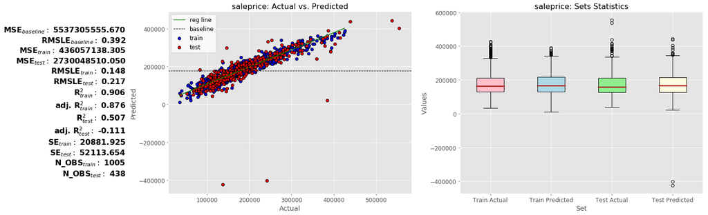

```python
reg_model_results_plots(model_summaries=ols_model_summaries)
```

### Residuals vs. Fitted

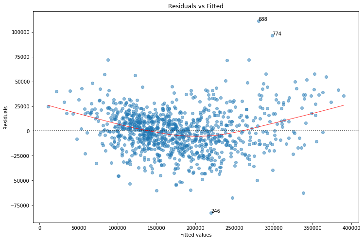

```python
resid_plot(ols_model_2, y_train)
```

The residuals are close to but not exactly spread around a horizontal line. There seems to be some non-linear relationships, that the model didn't capture.

```python
name = ['Jarque-Bera', 'Chi^2 two-tail prob.', 'Skew', 'Kurtosis']
test = sm.stats.jarque_bera(ols_model_2.resid)
lzip(name, test)
```

```
[('Jarque-Bera', 109.88071808276949),
 ('Chi^2 two-tail prob.', 1.379447684554185e-24),
 ('Skew', 0.24886519789751307),
 ('Kurtosis', 4.541519251046502)]
```

JB- Number is very high indicating that the residuals are not normally distributed.

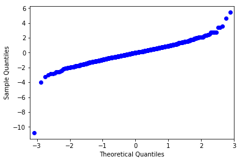

```python
sm.qqplot(ols_model_2.get_influence().resid_studentized_internal);
```

```python
# add_model_to_overview(ols_model_summaries, "OLS - removal of attributes")
```

## Ordinary Least Square Regression Model (Iteration 3)

- use scaled data

```python
ols_model_3 = sm.OLS(y_train_scaled, X_train_scaled).fit()
```

```python
ols_model_3, ols_model_3_summary, sign_attr_3=lin_model(y_train_scaled, X_train_scaled, y_test_scaled, X_test_scaled, reg_model="OLS")
```

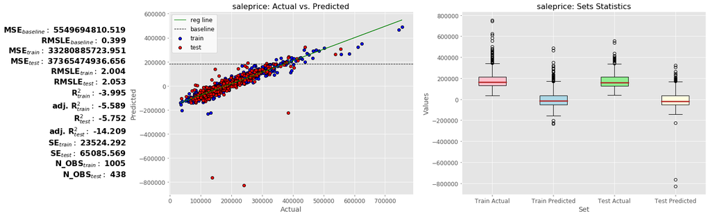

```python
reg_model_results_plots(model_summaries=ols_model_3_summary)
```

Using the standardized data results in a much worse result. WHY? We also have negative values, which should not be possible.

### Residuals vs. Fitted

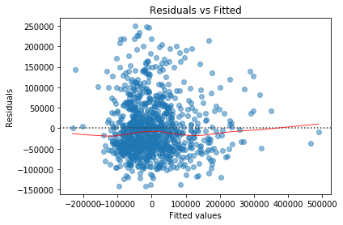

```python
# fitted values
model_fitted_y_2 = ols_model_3.fittedvalues;
# Basic plot
plot = sns.residplot(model_fitted_y_2, y_train, lowess=True,
                     scatter_kws={'alpha': 0.5},
                     line_kws={'color': 'red',
                               'lw': 1, 'alpha': 0.8});

plot.set_title('Residuals vs Fitted');
plot.set_xlabel('Fitted values');
plot.set_ylabel('Residuals');
```

## Ordinary Least Square - Cross Validation

- using the model from second iteration

```python
predictors=" + ".join(ols_model_sign_attr)
```

```python
predictors
```

```
'lotarea + overallqual + overallcond + yearremodadd + masvnrarea + bsmtfinsfone + totalbsmtsf + grlivarea + fireplaces + garagearea + wooddecksf + mszoning_fv + mszoning_rl + lotshape_irtwo + landslope_sev + neighborhood_edwards + neighborhood_mitchel + neighborhood_names + neighborhood_nwames + nei…
```

```python
# Model 1
results = cross_fold(df_hot1encoded, response='saleprice', predictors=predictors)
display(results)
print(f'MSE Mean: {results["MSE"].mean():.2f}')
print(f'RMSLE Mean: {results["RMSLE"].mean():.2f}')
```

|  | Fold | MSE | RMSLE |
| --- | --- | --- | --- |
| 0 | 0 | 6.387315e+08 | 0.159457 |
| 1 | 1 | 7.212496e+08 | 0.165185 |
| 2 | 2 | 1.400007e+09 | 0.136746 |
| 3 | 3 | 5.588037e+09 | 0.232696 |
| 4 | 4 | 7.395854e+08 | 0.141421 |
| 5 | 5 | 5.090950e+08 | 0.150639 |
| 6 | 6 | 9.754759e+08 | 0.253570 |
| 7 | 7 | 1.019725e+09 | 0.210303 |
| 8 | 8 | 2.668827e+09 | 0.177451 |
| 9 | 9 | 6.991393e+08 | 0.136425 |

```
MSE Mean: 1495987297.72
RMSLE Mean: 0.18
```

## Ordinary Least Square Iteration 4

- use natural log for the dependent variable to approach a normal distribution

```python
y_train_log= np.log(y_train)
y_test_log= np.log(y_test)
```

```python
ols_model_4, ols_model_summary_4, ols_sign_attr_4=lin_model(y_train_log, X_train, y_test_log, X_test, reg_model="OLS")
```

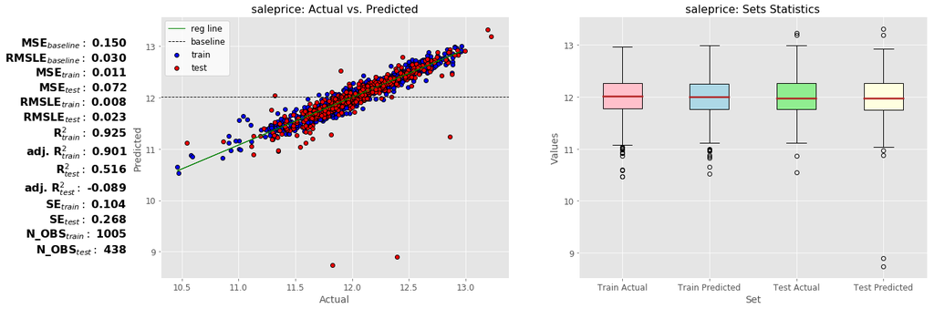

```python
reg_model_results_plots(model_summaries=ols_model_summary_4)
```

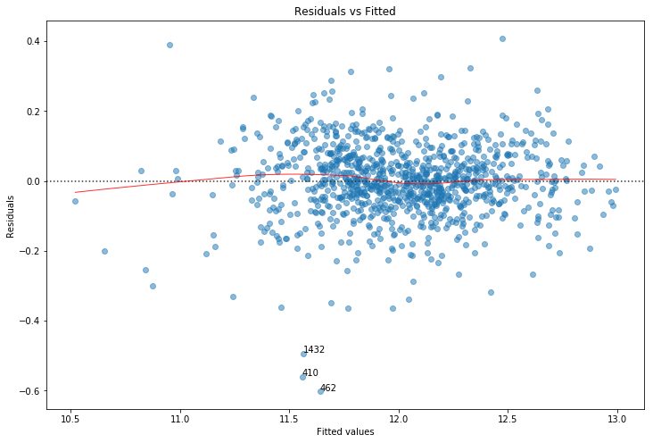

```python
resid_plot(ols_model_4, y_train_log)
```

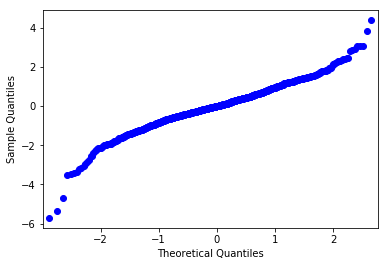

```python
sm.qqplot(ols_model_4.get_influence().resid_studentized_internal);
```

```python
ols_model_5, ols_model_summary_5, ols_sign_attr_5=lin_model(y_train, X_train, y_test, X_test, reg_model="OLS")
```

## General Least Square Regression

```python
gls_model, gls_model_summary, gls_sign_attr=lin_model(y_train, X_train, y_test, X_test, reg_model="GLS")
```

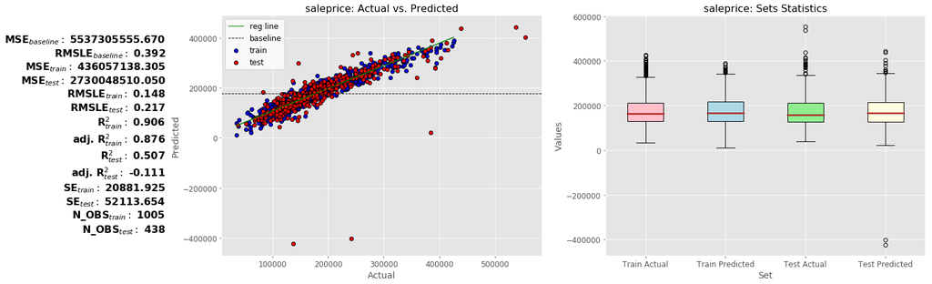

```python
reg_model_results_plots(model_summaries=gls_model_summary)
```

### Residuals vs. Fitted

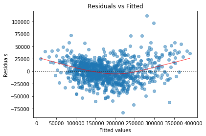

```python
# Basic plot
plot = sns.residplot(gls_model.fittedvalues, y_train, lowess=True,
                     scatter_kws={'alpha': 0.5},
                     line_kws={'color': 'red',
                               'lw': 1, 'alpha': 0.8});

plot.set_title('Residuals vs Fitted');
plot.set_xlabel('Fitted values');
plot.set_ylabel('Residuals');
```

```python
name = ['Jarque-Bera', 'Chi^2 two-tail prob.', 'Skew', 'Kurtosis']
test = sm.stats.jarque_bera(gls_model.resid)
lzip(name, test)
```

```
[('Jarque-Bera', 109.88071808276949),
 ('Chi^2 two-tail prob.', 1.379447684554185e-24),
 ('Skew', 0.24886519789751307),
 ('Kurtosis', 4.541519251046502)]
```

JB- Number is very high indicating that the residuals are not normally distributed.

## Lasso Regression Iteration 1

Lasso helps us to reduce dimensions and drop unimportant attributes.

```python
lasso1 = Lasso()
lasso1.set_params(alpha=0.5)
lasso1.fit(X_train, y_train)
print(lasso1.score(X_train, y_train))
print(lasso1.score(X_test, y_test))
```

```
0.9513775039481545
0.4586512103580049
```

```python
y_pred=lasso1.predict(X_test)
```

```python
lasso_coef1=pd.Series(lasso1.coef_, index=X_train.columns)
```

```python
(lasso_coef1[(lasso_coef1==0)].index.tolist())
```

```
['conditiontwo_posa',
 'conditiontwo_rrnn',
 'roofmatl_membran',
 'roofmatl_roll',
 'exterioronest_asphshn',
 'exterioronest_cblock',
 'exterioronest_imstucc',
 'exterioronest_plywood',
 'exteriortwond_asphshn',
 'exteriortwond_cblock',
 'exteriortwond_stone',
 'extercond_ta',
 'heating_gasa',
 'heatingqc_po',
 'poolqc_fa',
 'miscfeature_tenc',
 'saletype_con']
```

```python
# make function to get number of irrelevant attributes
def get_irr_attr_lasso(lasso_model, X_train):
    lasso_coef=pd.Series(lasso_model.coef_, index=X_train.columns)
    irr_attr_lasso=lasso_coef[(lasso_coef==0)].index.tolist()
    return irr_attr_lasso
```

```python
# make function to get number of irrelevant attributes
def get_attr_lasso(lasso_model, X_train):
    lasso_coef=pd.Series(lasso_model.coef_, index=X_train.columns)
    attr_lasso=lasso_coef[(lasso_coef!=0)].index.tolist()
    return attr_lasso
```

```python
get_irr_attr_lasso(lasso1, X_train)
```

```
['conditiontwo_posa',
 'conditiontwo_rrnn',
 'roofmatl_membran',
 'roofmatl_roll',
 'exterioronest_asphshn',
 'exterioronest_cblock',
 'exterioronest_imstucc',
 'exterioronest_plywood',
 'exteriortwond_asphshn',
 'exteriortwond_cblock',
 'exteriortwond_stone',
 'extercond_ta',
 'heating_gasa',
 'heatingqc_po',
 'poolqc_fa',
 'miscfeature_tenc',
 'saletype_con']
```

```python
lasso_attr=lasso_coef1[lasso_coef1!=0]
```

```python
lasso_attr.shape
```

```
(226,)
```

We have 226 attributes considered as important.

```python
lasso_attr=lasso_attr.index.tolist()
```

```python
lasso = Lasso()
lasso.set_params(alpha=0.5)
lasso.fit(X_train[lasso_attr], y_train)
print(lasso.score(X_train[lasso_attr], y_train))
print(lasso.score(X_test[lasso_attr], y_test))
```

```
0.9513775128519615
0.4586519138078587
```

```python
y_pred=lasso.predict(X_test[lasso_attr])
```

```python
mse_test, r2_test, adj_r2_test, st_error_test = regression_model_metrics(y_test, y_pred, X_test)
```

```python
lasso, lasso_summaries =  get_model_results(lasso,y_train, X_train[lasso_attr], y_test, X_test[lasso_attr])
```

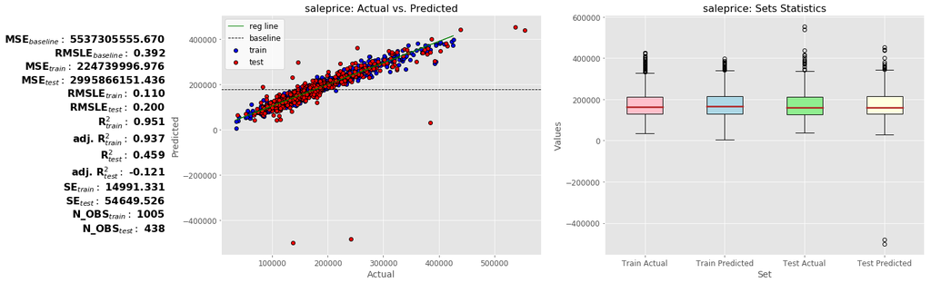

```python
reg_model_results_plots(lasso_summaries)
```

## Lasso Regression Iteration 2

- iteratively removing irrelevant attributes based on lasso/coefficients

```python
lasso2 = Lasso()
lasso2.set_params(alpha=0.5)
lasso2.fit(X_train, y_train)

X_train_lasso=X_train.copy()
while len(get_irr_attr_lasso(lasso2, X_train_lasso))>0:
    lasso_attr=get_attr_lasso(lasso2, X_train_lasso)
    X_train_lasso=X_train[lasso_attr]
    lasso2.fit(X_train_lasso, y_train)


print(lasso2.score(X_train[lasso_attr], y_train))
print(lasso2.score(X_test[lasso_attr], y_test))
```

```
0.9513775128519615
0.4586519138078587
```

```python
len(get_irr_attr_lasso(lasso2, X_train_lasso))
```

```
0
```

```python
len(get_attr_lasso(lasso2, X_train_lasso))
```

```
226
```

```python
lasso2, lasso_summaries2 =  get_model_results(lasso2,y_train, X_train[lasso_attr], y_test, X_test[lasso_attr])
```

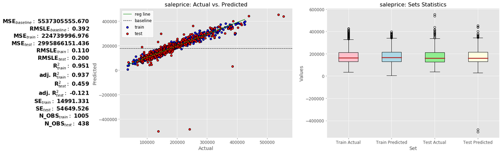

```python
reg_model_results_plots(lasso_summaries2)
```

No difference

This didn't improve the model at all.

## Lasso Regression Iteration 3

- Using various alphas and comparing results

```python
def lasso_r2(lambdas, X_train, y_train, X_test, y_test):
    '''
    Takes in a list of lambdas.
    Outputs a dataframe containing the r2 of lasso regressions
    from each lambda for training and testing data set.

    '''
    columns_list=["lambda", "R2_training", "R2_testing"]
    r_scores=pd.DataFrame(columns=columns_list)

    for l in lambdas:
        lasso=Lasso()
        lasso.set_params(alpha=l)
        lasso.fit(X_train, y_train)
        R2_train=lasso.score(X_train, y_train)
        R2_test=lasso.score(X_test, y_test)
        row=pd.DataFrame([[l,R2_train, R2_test]], columns=columns_list)
        r_scores=r_scores.append(row)
    return r_scores

def plot_lasso_lambdas(r_scores):
    plt.figure(figsize=(15,8))
    ax=plt.plot( 'lambda', 'R2_training', data=r_scores, marker='o', markerfacecolor='blue', markersize=12, color='skyblue', linewidth=4)
    ax=plt.plot( 'lambda', 'R2_testing', data=r_scores, marker='o', markerfacecolor='red', markersize=12, color='tomato', linewidth=4)
#     plt.xscale("log")
    plt.legend()
```

```python
l_min = 0.05
l_max = 20
l_num = 20
lambdas = np.linspace(l_min,l_max, l_num)
```

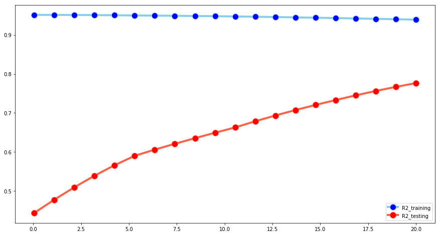

```python
plot_lasso_lambdas(lasso_r2(lambdas, X_train, y_train, X_test, y_test))
```

```python
lasso_r2_results=lasso_r2(lambdas, X_train, y_train, X_test, y_test)
```

```python
lasso_r2_results=lasso_r2_results.reset_index().drop(columns="index")
```

```python
lasso_r2_results["R2_testing"].idxmax()
```

```
19
```

```python
lasso_r2_results.ix[lasso_r2_results["R2_testing"].idxmax()]
```

```
lambda         20.000000
R2_training     0.939235
R2_testing      0.776515
Name: 19, dtype: float64
```

```python
lasso3=Lasso()
lasso3.set_params(alpha=11.6)
lasso3.fit(X_train[lasso_attr], y_train)
```

```
Lasso(alpha=11.6, copy_X=True, fit_intercept=True, max_iter=1000,
   normalize=False, positive=False, precompute=False, random_state=None,
   selection='cyclic', tol=0.0001, warm_start=False)
```

```python
lasso3, lasso_summaries3 =  get_model_results(lasso3,y_train, X_train[lasso_attr], y_test, X_test[lasso_attr])
```

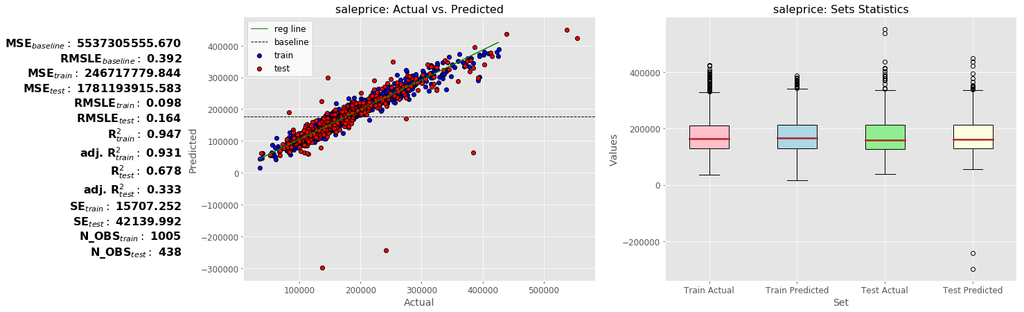

```python
reg_model_results_plots(lasso_summaries3)
```

Clearly overfitted. MSE for testing set is much higher than for testing set

```python
len(get_attr_lasso(lasso3, X_train[lasso_attr]))
```

```
196
```

```python
get_attr_lasso(lasso3, X_train[lasso_attr])
```

```
['mssubclass',
 'lotfrontage',
 'lotarea',
 'overallqual',
 'overallcond',
 'yearbuilt',
 'yearremodadd',
 'masvnrarea',
 'bsmtfinsfone',
 'bsmtfinsftwo',
 'bsmtunfsf',
 'totalbsmtsf',
 'onestflrsf',
 'twondflrsf',
 'lowqualfinsf',
 'grlivarea',
 'bsmtfullbath',
 'bsmthalfbath',
 'fullbath',
 'halfbath',
 'bedroomabvgr',
 'kitchenabvgr',
 'totrmsabvgrd',
 'fireplaces',
 'garageyrblt',
 'garagecars',
 'garagearea',
 'wooddecksf',
 'openporchsf',
 'enclosedporch',
 'threessnporch',
 'screenporch',
 'poolarea',
 'miscval',
 'mosold',
 'yrsold',
 'mszoning_fv',
 'mszoning_rh',
 'mszoning_rl',
 'mszoning_rm',
```

[output cut: 141 more lines]

```
 'poolqc_gd',
 'fence_mnprv',
 'fence_mnww',
 'miscfeature_othr',
 'miscfeature_shed',
 'saletype_cwd',
 'saletype_conld',
 'saletype_new',
 'saletype_oth',
 'saletype_wd',
 'salecondition_adjland',
 'salecondition_alloca',
 'salecondition_family',
 'salecondition_normal',
 'salecondition_partial']
```

## Lasso Regression Iteration 4

used normalized data.

```python
lasso=Lasso()
lasso.set_params(alpha=11.6)
lasso.fit(X_train_scaled, y_train)
```

```
Lasso(alpha=11.6, copy_X=True, fit_intercept=True, max_iter=1000,
   normalize=False, positive=False, precompute=False, random_state=None,
   selection='cyclic', tol=0.0001, warm_start=False)
```

```python
lasso_r2_results_2=lasso_r2(lambdas, X_train_scaled[lasso_attr], y_train, X_test_scaled[lasso_attr], y_test)
lasso_r2_results_2=lasso_r2_results_2.reset_index().drop(columns="index")
lasso_r2_results_2.ix[lasso_r2_results_2["R2_testing"].idxmax()]
```

```
lambda         20.000000
R2_training     0.218484
R2_testing     -0.214018
Name: 19, dtype: float64
```

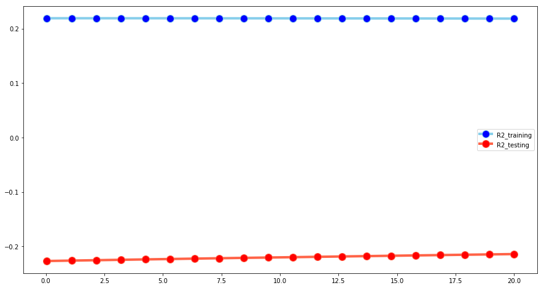

```python
plot_lasso_lambdas(lasso_r2(lambdas, X_train_scaled[lasso_attr], y_train, X_test_scaled[lasso_attr], y_test))
```

```python
lasso4=Lasso()
lasso4.set_params(alpha=20)
lasso4.fit(X_train_scaled[lasso_attr], y_train)
```

```
Lasso(alpha=20, copy_X=True, fit_intercept=True, max_iter=1000,
   normalize=False, positive=False, precompute=False, random_state=None,
   selection='cyclic', tol=0.0001, warm_start=False)
```

```python
lasso4, lasso_summaries_4 =  get_model_results(lasso4,y_train, X_train_scaled[lasso_attr], y_test, X_test_scaled[lasso_attr])
```

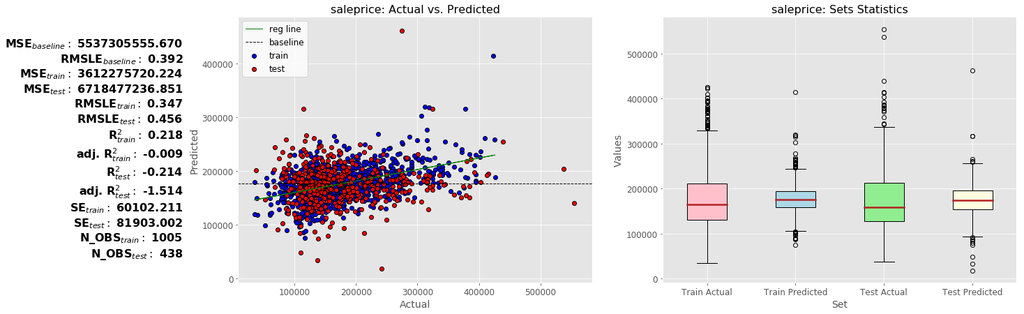

```python
reg_model_results_plots(lasso_summaries_4)
```

Like before it got worse. Especially the adj. R2 is significantly lower.

## Lasso Regression iteration 5

Crossvalidation

```python
lasso_5 = LassoCV(cv=10, random_state=0, normalize=True).fit(X, y)
lasso_5.score(X,y)
```

```
0.8744423400206691
```

```python
lasso_5, lasso_summaries_5 =  get_model_results(lasso_5,y, X, y, X)
```

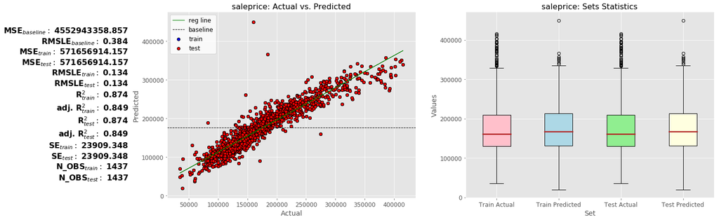

```python
reg_model_results_plots(lasso_summaries_5)
```

This time using the normalization parameter provides better results

```python
display(get_attr_lasso(lasso_5, X_train))
display(len(get_attr_lasso(lasso_5, X_train)))
```

```
['mssubclass',
 'lotarea',
 'overallqual',
 'overallcond',
 'yearbuilt',
 'yearremodadd',
 'masvnrarea',
 'bsmtfinsfone',
 'totalbsmtsf',
 'grlivarea',
 'bsmtfullbath',
 'kitchenabvgr',
 'totrmsabvgrd',
 'fireplaces',
 'garagecars',
 'garagearea',
 'wooddecksf',
 'openporchsf',
 'screenporch',
 'mszoning_rm',
 'lotshape_irthree',
 'landcontour_hls',
 'lotconfig_culdsac',
 'landslope_mod',
 'neighborhood_crawfor',
 'neighborhood_edwards',
 'neighborhood_noridge',
 'neighborhood_nridght',
 'neighborhood_somerst',
 'neighborhood_stonebr',
 'neighborhood_veenker',
 'conditionone_norm',
 'conditiontwo_posa',
 'conditiontwo_posn',
 'bldgtype_duplex',
 'bldgtype_twnhs',
 'roofstyle_gable',
 'exterioronest_brkface',
 'exterioronest_hdboard',
 'exterioronest_wd_sdng',
 'exteriortwond_cmentbd',
 'exteriortwond_stucco',
 'exteriortwond_wd_shng',
 'exterqual_ta',
 'foundation_pconc',
 'bsmtexposure_gd',
 'bsmtexposure_no',
 'bsmtfintypeone_glq',
 'bsmtfintypeone_unf',
 'heating_othw',
 'kitchenqual_ta',
 'functional_sev',
 'functional_typ',
 'fireplacequ_gd',
 'garagetype_detchd',
 'garagefinish_unf',
 'garagequal_gd',
 'poolqc_gd',
 'saletype_new']
```

```
59
```

```python
get_irr_attr_lasso(lasso_5, X_train)
```

```
['lotfrontage',
 'bsmtfinsftwo',
 'bsmtunfsf',
 'onestflrsf',
 'twondflrsf',
 'lowqualfinsf',
 'bsmthalfbath',
 'fullbath',
 'halfbath',
 'bedroomabvgr',
 'garageyrblt',
 'enclosedporch',
 'threessnporch',
 'poolarea',
 'miscval',
 'mosold',
 'yrsold',
 'mszoning_fv',
 'mszoning_rh',
 'mszoning_rl',
 'alley_pave',
 'lotshape_irtwo',
 'lotshape_reg',
 'landcontour_low',
 'landcontour_lvl',
 'lotconfig_frtwo',
 'lotconfig_frthree',
 'lotconfig_inside',
 'landslope_sev',
 'neighborhood_blueste',
 'neighborhood_brdale',
 'neighborhood_brkside',
 'neighborhood_clearcr',
 'neighborhood_collgcr',
 'neighborhood_gilbert',
 'neighborhood_idotrr',
 'neighborhood_meadowv',
 'neighborhood_mitchel',
 'neighborhood_names',
 'neighborhood_npkvill',
```

[output cut: 129 more lines]

```
 'miscfeature_othr',
 'miscfeature_shed',
 'miscfeature_tenc',
 'saletype_cwd',
 'saletype_con',
 'saletype_conld',
 'saletype_conli',
 'saletype_conlw',
 'saletype_oth',
 'saletype_wd',
 'salecondition_adjland',
 'salecondition_alloca',
 'salecondition_family',
 'salecondition_normal',
 'salecondition_partial']
```

```python
lasso_5_coef = pd.Series(lasso_5.coef_, index = X_train.columns).sort_values()
lasso_5_coef = lasso_5_coef[lasso_5_coef!=0]
```

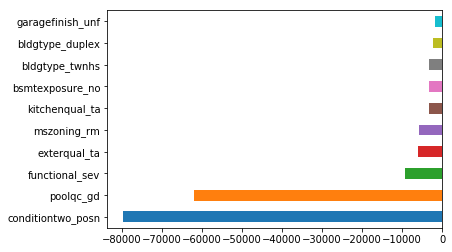

```python
lasso_5_coef.head(10).plot(kind="barh")
```

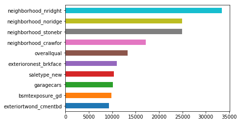

```python
lasso_5_coef.tail(10).plot(kind="barh")
```

## Lasso Regression Iteration 6

- Cross validation
- optimization of alphas

```python
l_min = 0.05
l_max = 20
l_num = 20
lambdas = np.linspace(l_min,l_max, l_num)
```

```python
lasso6 = LassoCV(cv=10, random_state=0, alphas=lambdas, fit_intercept=True).fit(X, y)
lasso6.score(X,y)
```

```
0.9135961619563597
```

```python
lasso6, lasso_summaries_6 =  get_model_results(lasso6,y, X, y, X)
```

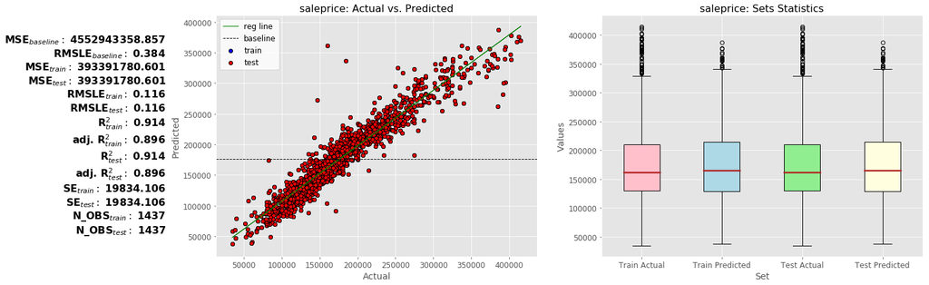

```python
reg_model_results_plots(lasso_summaries_6)
```

```python
lasso6.alpha_
```

```
20.0
```

Best alpha: 20

Using an intercept and an optimization of the alphas results in quite a good result. The RMSLE is very low in comparison and also the R2 is good.

## Elastic Nets Iteration 1

Especially, when you have **a lot** of attributes. Elastic Nets are especially good at dealing with correlations between parameters, which we strongly assume is the case here. For our example, we have over 200 attributes. This is what we would also consider as a lot. This is why elastic nets sound quite promising for our example. Elastic Nets is a combination of Lasso and Ridge Regression.

We will use CV for this only.

```python
alphas = [0.0005, 0.001, 0.01, 0.03, 0.05, 0.1]
l1_ratios = [ .1, .5, .7, .8, .9, .95, .99, 1]
```

```python
ElasticNet1 = ElasticNetCV(cv=5, random_state=0, l1_ratio =l1_ratios, alphas=lambdas, fit_intercept=True )
```

```python
ElasticNet1.fit(X, y)
```

```
ElasticNetCV(alphas=array([ 0.05,  1.1 ,  2.15,  3.2 ,  4.25,  5.3 ,  6.35,  7.4 ,  8.45,
        9.5 , 10.55, 11.6 , 12.65, 13.7 , 14.75, 15.8 , 16.85, 17.9 ,
       18.95, 20.  ]),
       copy_X=True, cv=5, eps=0.001, fit_intercept=True,
       l1_ratio=[0.1, 0.5, 0.7, 0.8, 0.9, 0.95, 0.99, 1], max_iter=1000,
       n_alphas=100, n_jobs=None, normalize=False, positive=False,
       precompute='auto', random_state=0, selection='cyclic', tol=0.0001,
       verbose=0)
```

```python
ElasticNet1, ElasticNet1_summaries =  get_model_results(ElasticNet1,y, X, y, X)
```

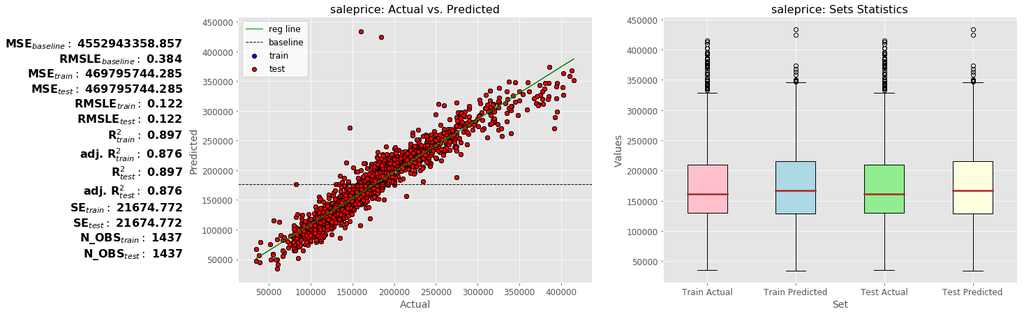

```python
reg_model_results_plots(ElasticNet1_summaries)
```

```python
print("L1 ratio: ", ElasticNet1.l1_ratio_)
print("Alpha: ", ElasticNet1.alpha_)
```

```
L1 ratio:  0.99
Alpha:  1.1
```

The L1 ration is close to one, which means that this is very close to the Lasso regression. Still the Lasso yield better results.

```python
el_net_coef = pd.Series(ElasticNet1.coef_, index = X_train.columns)
```

```python
el_net_coef=el_net_coef.sort_values()
```

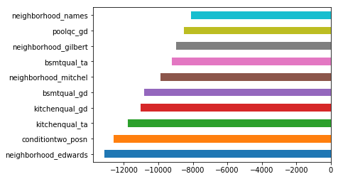

```python
el_net_coef.head(10).plot(kind="barh")
```

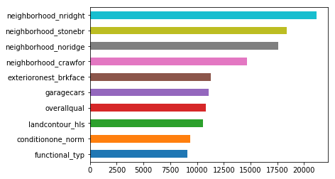

```python
el_net_coef.tail(10).plot(kind="barh")
```

```python
print("Elastic Net picked " + str(sum(el_net_coef != 0)) + " variables and eliminated the other " +  str(sum(el_net_coef == 0)) + " variables")
```

```
Elastic Net picked 239 variables and eliminated the other 4 variables
```

Only 4 Variables were eliminated. --> not really helpful.

## Some other methods: KNN-Regression

```python
n_neighbors = 10
```

```python
knn = KNeighborsRegressor(n_neighbors=n_neighbors)
knn.fit(X_train, y_train)
```

```
KNeighborsRegressor(algorithm='auto', leaf_size=30, metric='minkowski',
          metric_params=None, n_jobs=None, n_neighbors=10, p=2,
          weights='uniform')
```

```python
knn, knn_summaries =  get_model_results(knn,y_train, X_train, y_test, X_test)
```

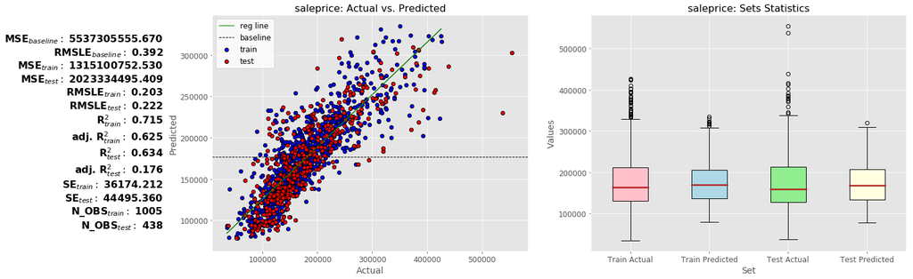

```python
reg_model_results_plots(knn_summaries)
```

As expected, the results are not very good. The model particularly does not handle values in the upper end very well. However, here we could also tune the hyperparameters and test for different numbers of n_neighbors:

```python
params = {'n_neighbors':[2,3,4,5,6,7,8,9]}

knn = KNeighborsRegressor()

knn_opt = GridSearchCV(knn, params, cv=5)
knn_opt.fit(X_train,y_train)
knn_opt.best_params_
```

```
{'n_neighbors': 4}
```

```python
knn = KNeighborsRegressor(n_neighbors=4)
knn.fit(X_train, y_train)
knn, knn_summaries =  get_model_results(knn,y_train, X_train, y_test, X_test)
```

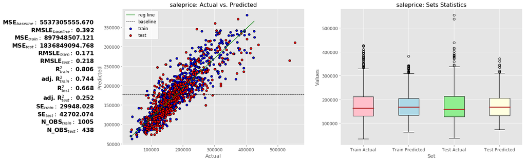

```python
reg_model_results_plots(knn_summaries)
```

The RMSLE for the test set did not improve that much. The other regression techniques are still better and they provide more possibilities to assess the attributes with regard to their importances.

## PCA Analysis

```python
X_values=X.values
y_values=y.values
```

```python
y.values
```

```
array([208500, 181500, 223500, ..., 266500, 142125, 147500], dtype=int64)
```

```python
# As we do not know how many components to choose, we select "None"
# as number of components to get an overview over the variance in the dataset
pca= PCA(n_components=None)
X_values_scaled= StandardScaler().fit_transform(X_values)
X_values_scaled= pca.fit_transform(X_values_scaled)
```

```python
# We check our explained variance ratio in the dataset by adding each
# consecutive principal component
np.cumsum(np.round(pca.explained_variance_ratio_,decimals=4)*100)
```

```
array([ 6.36,  9.47, 11.77, 13.89, 15.65, 17.24, 18.76, 20.12, 21.42,
       22.66, 23.86, 25.05, 26.16, 27.27, 28.35, 29.4 , 30.43, 31.42,
       32.38, 33.33, 34.24, 35.13, 36.01, 36.88, 37.75, 38.59, 39.41,
       40.23, 41.04, 41.82, 42.6 , 43.36, 44.12, 44.86, 45.58, 46.29,
       46.99, 47.68, 48.37, 49.05, 49.73, 50.39, 51.04, 51.68, 52.31,
       52.94, 53.55, 54.16, 54.76, 55.36, 55.95, 56.53, 57.1 , 57.67,
       58.23, 58.78, 59.33, 59.87, 60.41, 60.94, 61.46, 61.98, 62.49,
       63.  , 63.51, 64.01, 64.5 , 64.99, 65.47, 65.95, 66.43, 66.91,
       67.38, 67.85, 68.32, 68.78, 69.24, 69.7 , 70.15, 70.6 , 71.04,
       71.48, 71.91, 72.34, 72.77, 73.2 , 73.62, 74.04, 74.45, 74.86,
       75.26, 75.66, 76.05, 76.44, 76.83, 77.21, 77.59, 77.97, 78.34,
       78.71, 79.07, 79.43, 79.78, 80.13, 80.48, 80.82, 81.16, 81.49,
       81.82, 82.15, 82.48, 82.81, 83.13, 83.45, 83.77, 84.08, 84.39,
       84.7 , 85.  , 85.3 , 85.6 , 85.89, 86.18, 86.47, 86.75, 87.03,
       87.31, 87.58, 87.85, 88.11, 88.37, 88.63, 88.88, 89.13, 89.38,
       89.63, 89.87, 90.11, 90.34, 90.57, 90.8 , 91.03, 91.25, 91.47,
       91.69, 91.91, 92.12, 92.32, 92.52, 92.72, 92.92, 93.12, 93.31,
       93.5 , 93.69, 93.87, 94.05, 94.23, 94.41, 94.58, 94.75, 94.92,
       95.08, 95.24, 95.4 , 95.56, 95.71, 95.86, 96.01, 96.15, 96.29,
       96.43, 96.57, 96.7 , 96.83, 96.96, 97.08, 97.2 , 97.32, 97.44,
       97.55, 97.66, 97.76, 97.86, 97.96, 98.05, 98.14, 98.23, 98.32,
       98.41, 98.49, 98.57, 98.65, 98.73, 98.8 , 98.87, 98.94, 99.01,
       99.07, 99.13, 99.19, 99.25, 99.3 , 99.35, 99.4 , 99.45, 99.49,
       99.53, 99.57, 99.61, 99.65, 99.68, 99.71, 99.74, 99.77, 99.79,
       99.81, 99.83, 99.85, 99.87, 99.89, 99.91, 99.92, 99.93, 99.94,
       99.95, 99.96, 99.97, 99.98, 99.99, 99.99, 99.99, 99.99, 99.99,
       99.99, 99.99, 99.99, 99.99, 99.99, 99.99, 99.99, 99.99, 99.99])
```

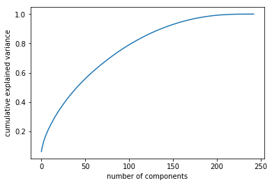

```python
# For better understanding we plot the variance curve.
plt.plot(np.cumsum(pca.explained_variance_ratio_))
plt.xlabel('number of components')
plt.ylabel('cumulative explained variance');
```

## PCR Analysis

```python
def pcr(X,y,pc):
    pca3 = PCA()

    X_r= StandardScaler().fit_transform(X)
    X_r= pca.fit_transform(X)

    # Run PCA producing the reduced variable Xreg and select the first pc components
    Xreg = pca.fit_transform(X_r)[:,:pc]

    ''' Step 2: regression on selected principal components'''

    # Create linear regression object
    regr = LinearRegression()

    # Fit
    regr.fit(Xreg, y)

    # prediction of calibration
    y_c = regr.predict(Xreg)

    # Cross-validation
    y_cv = cross_val_predict(regr, Xreg, y, cv=10)

    # Calculate scores for calibration and cross-validation
    score_c = r2_score(y, y_c)
    score_cv = r2_score(y, y_cv)

    # Calculate mean square error for calibration and cross validation
    mse_c = mean_squared_error(y, y_c)
    mse_cv = mean_squared_error(y, y_cv)

    return(regr, y_cv, score_c, score_cv, mse_c, mse_cv, Xreg)
```

```python
pcr, predicted, r2r, r2cv, mser, mscv, x_pcr=pcr(X_values,y_values, pc=6)
```

```python
r2r
```

```
0.6099055445852217
```

```python
pcr, pcr_summaries = get_model_results(pcr,y,x_pcr, y, x_pcr)
```

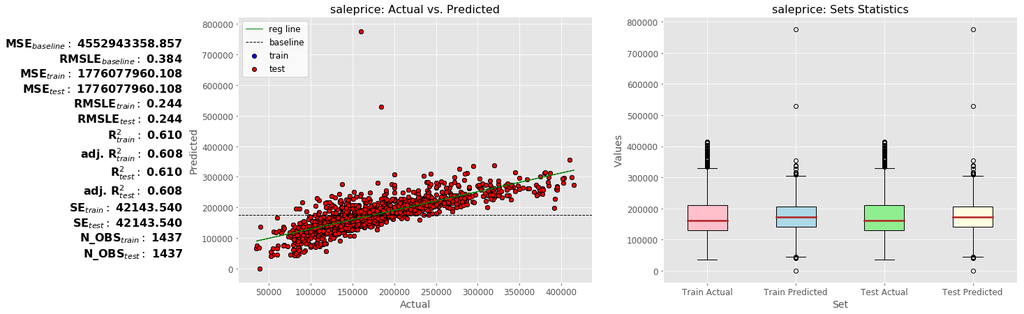

```python
reg_model_results_plots(pcr_summaries)
```

## PLS

Partial Least Squares:

- Extension of a multiple linear regression model without restrictions
- Technique similar to Principal Component Analysis (PCA).
- Decomposes both the design matrix X and response vector/matrix Y (can have multiple responses at once) like in PCA and then performs regression between the obtained scores matrix and the eigenvectors.
- The idea is to obtain decomposition of X and Y to be done by taking information from each other into account.

```python
X_train_values=X_train.values
y_train_values=y_train.values
X_test_values=X_test.values
y_test_values=y_test.values
```

```python
mse=[]
component = np.arange(1,50)
```

```python
for i in component:
    pls1= PLSRegression(n_components=i)
    pls1.fit(X_train_values,y_train_values)
    y_pred = pls1.predict(X_test_values)

    mse_p = mean_squared_error(y_test_values,y_pred)
    mse.append(mse_p)
```

```python
np.argmin(mse)
```

```
1
```

```python
msemin = np.argmin(mse)
print("Suggested number of components: ", msemin+1)
```

```
Suggested number of components:  2
```

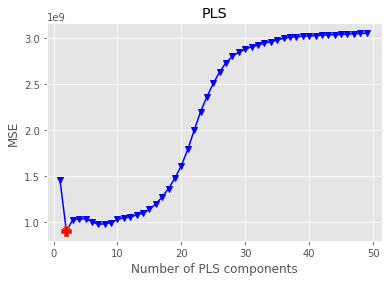

```python
with plt.style.context(('ggplot')):
     plt.plot(component, np.array(mse), '-v', color = 'blue', mfc='blue')
     plt.plot(component[msemin], np.array(mse)[msemin], 'P', ms=10, mfc='red')
     plt.xlabel('Number of PLS components')
     plt.ylabel('MSE')
     plt.title('PLS')
     plt.xlim(xmin=-1)

     plt.show()
```

```python
pls = PLSRegression(n_components=msemin+1)
pls.fit(X_train, y_train)
Y_pred = pls.predict(X_test)
```

```python
pls, pls_summaries = get_model_results(pls,y_train,X_train, y_test, X_test)
```

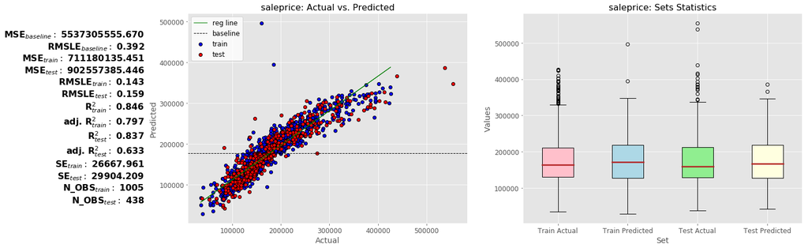

```python
reg_model_results_plots(pls_summaries)
```

## XGBoost

```python
X_train = pd.DataFrame(data=X_train, columns=FEATURE_COLS)
X_test = pd.DataFrame(data=X_test, columns=FEATURE_COLS)
```

```python
# DMatrix is a internal data structure that used by XGBoost which is optimized for both memory efficiency and training speed
data_dmatrix =xgb.DMatrix(data=X_train,label=y_train)
```

```python
xg_reg = xgb.XGBRegressor(objective ='reg:linear', colsample_bytree = 0.3, learning_rate = 0.1,
         max_depth = 5, alpha = 10, n_estimators = 100)
```

```python
xg_reg.fit(X_train,y_train)

preds = xg_reg.predict(X_test)
```

```python
xg_reg, xg_reg_summaries = get_model_results(xg_reg,y_train,X_train, y_test, X_test)
```

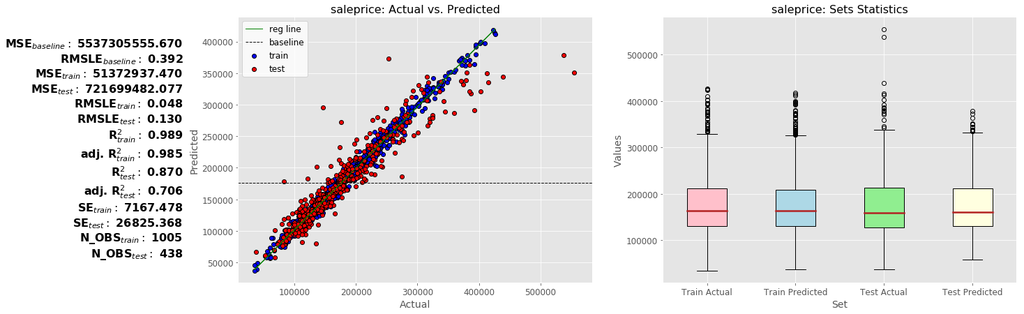

```python
reg_model_results_plots(xg_reg_summaries)
```

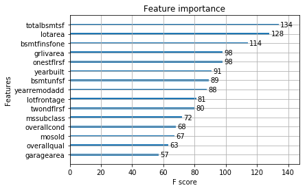

```python
xgb.plot_importance(xg_reg,max_num_features=15)
plt.show()
```

```python
params = {"objective":"reg:linear",'colsample_bytree': 0.3,'learning_rate': 0.1,
          'max_depth': 5, 'alpha': 10, "n_estimators" : 100}

cv_results = xgb.cv(dtrain=data_dmatrix, params=params, nfold=3,
                    num_boost_round=50,early_stopping_rounds=10,metrics="rmse", as_pandas=True, seed=123)
```

[output not shown]

[output cut: 95 more lines]

[output not shown]

```python
cv_results.head()
```

|  | train-rmse-mean | train-rmse-std | test-rmse-mean | test-rmse-std |
| --- | --- | --- | --- | --- |
| 0 | 171257.927083 | 675.518980 | 171493.713542 | 1307.106605 |
| 1 | 155225.546875 | 520.249460 | 155682.963542 | 1451.739619 |
| 2 | 140662.671875 | 421.011447 | 141354.619792 | 1209.744983 |
| 3 | 127583.893230 | 345.819646 | 128328.757813 | 1071.442562 |
| 4 | 115822.645834 | 388.631008 | 116730.356771 | 1119.723189 |

```python
print('Best number of trees = {}'.format(cv_results.shape[0]))
```

```
Best number of trees = 50
```